# 12_rotate_2D_points

## 12_rotate_2D_points

#### Question

## Matrix of original points (preimage)

1. A list of 2D-cartesian points is stored as the preimage matrix. Each column represents one point.

   $$P = \begin{bmatrix}
   4 & 2 & -6 & 0 & -2 & 0 & 5 & 6 & 3 & 0 & -5 & -7\\
   2 & 0 & -4 & 1 & -7 & 1 & 6 & 1 & -2 & -5 & -5 & -4
   \end{bmatrix}$$

   ```
   P = matrix([[4,2,-6,0,-2,0,5,6,3,0,-5,-7],[2,0,-4,1,-7,1,6,1,-2,-5,-5,-4]])
   ```

## Rotation matrix

   We want to rotate the points by $\theta=0.11$ radians counterclockwise. We will do this by [matrix multiplication with the 2D rotation matrix](https://en.wikipedia.org/wiki/Rotation_matrix).

   $$R = \begin{bmatrix}\cos(\theta) & -\sin(\theta) \\ \sin(\theta) & \cos(\theta) \end{bmatrix}$$

## Image

   We can apply the rotation to the points through matrix multiplication. Remember, matrix multiplication is not commutative. Let $T$ represent a matrix holding the final positions of the image (after the transformation).

   $$T = RP$$

   After you calculate $T$, you can plot the points in $T$ with the following code (in SageMath):

   ```
   point(T.transpose(),xmin=-10,xmax=10,ymin=-10,ymax=10,size=50)
   ```

   Which is the graph of the points in $T$? (Please excuse minor stylistic differences due to my graphs being made in R, not SageMath.)

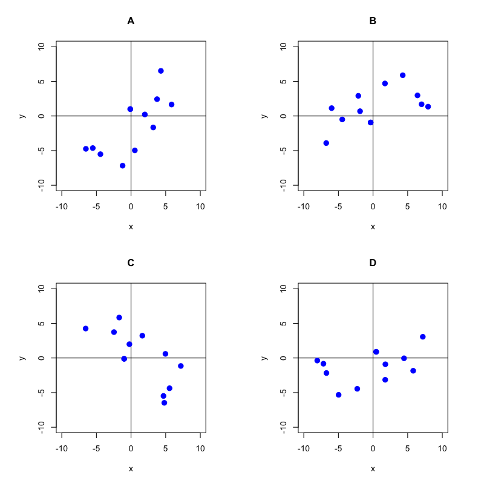

   1. A
   2. B
   3. C
   4. D

#### Question

## Matrix of original points (preimage)

2. A list of 2D-cartesian points is stored as the preimage matrix. Each column represents one point.

   $$P = \begin{bmatrix}
   -3 & 3 & -6 & 2 & -6 & 4 & 6 & 1 & -5 & -7 & -2 & -2\\
   -4 & 1 & 4 & -6 & 4 & -2 & 2 & -1 & -3 & 1 & 4 & 1
   \end{bmatrix}$$

   ```
   P = matrix([[-3,3,-6,2,-6,4,6,1,-5,-7,-2,-2],[-4,1,4,-6,4,-2,2,-1,-3,1,4,1]])
   ```

## Rotation matrix

   We want to rotate the points by $\theta=0.18$ radians counterclockwise. We will do this by [matrix multiplication with the 2D rotation matrix](https://en.wikipedia.org/wiki/Rotation_matrix).

   $$R = \begin{bmatrix}\cos(\theta) & -\sin(\theta) \\ \sin(\theta) & \cos(\theta) \end{bmatrix}$$

## Image

   We can apply the rotation to the points through matrix multiplication. Remember, matrix multiplication is not commutative. Let $T$ represent a matrix holding the final positions of the image (after the transformation).

   $$T = RP$$

   After you calculate $T$, you can plot the points in $T$ with the following code (in SageMath):

   ```
   point(T.transpose(),xmin=-10,xmax=10,ymin=-10,ymax=10,size=50)
   ```

   Which is the graph of the points in $T$? (Please excuse minor stylistic differences due to my graphs being made in R, not SageMath.)

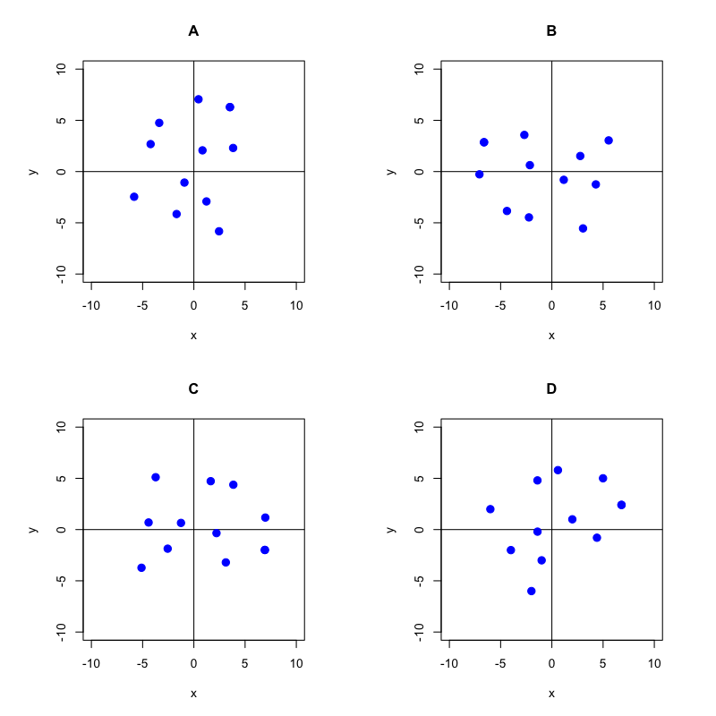

   1. A
   2. B
   3. C
   4. D

#### Question

## Matrix of original points (preimage)

3. A list of 2D-cartesian points is stored as the preimage matrix. Each column represents one point.

   $$P = \begin{bmatrix}
   -7 & -5 & 0 & -6 & -6 & -1 & -4 & 0 & -3 & -1 & 4\\
   4 & -5 & 3 & -1 & -6 & 6 & 6 & 2 & -7 & -4 & 4
   \end{bmatrix}$$

   ```
   P = matrix([[-7,-5,0,-6,-6,-1,-4,0,-3,-1,4],[4,-5,3,-1,-6,6,6,2,-7,-4,4]])
   ```

## Rotation matrix

   We want to rotate the points by $\theta=5.64$ radians counterclockwise. We will do this by [matrix multiplication with the 2D rotation matrix](https://en.wikipedia.org/wiki/Rotation_matrix).

   $$R = \begin{bmatrix}\cos(\theta) & -\sin(\theta) \\ \sin(\theta) & \cos(\theta) \end{bmatrix}$$

## Image

   We can apply the rotation to the points through matrix multiplication. Remember, matrix multiplication is not commutative. Let $T$ represent a matrix holding the final positions of the image (after the transformation).

   $$T = RP$$

   After you calculate $T$, you can plot the points in $T$ with the following code (in SageMath):

   ```
   point(T.transpose(),xmin=-10,xmax=10,ymin=-10,ymax=10,size=50)
   ```

   Which is the graph of the points in $T$? (Please excuse minor stylistic differences due to my graphs being made in R, not SageMath.)

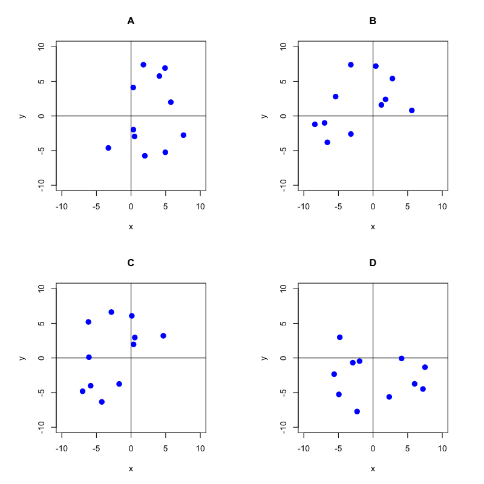

   1. A
   2. B
   3. C
   4. D

#### Question

## Matrix of original points (preimage)

4. A list of 2D-cartesian points is stored as the preimage matrix. Each column represents one point.

   $$P = \begin{bmatrix}
   -5 & 7 & 6 & 6 & 3 & -7 & 2 & -5 & 5 & 5 & 2 & 5\\
   -1 & 7 & -1 & -2 & 7 & 7 & 0 & -4 & -2 & 1 & -1 & -7
   \end{bmatrix}$$

   ```
   P = matrix([[-5,7,6,6,3,-7,2,-5,5,5,2,5],[-1,7,-1,-2,7,7,0,-4,-2,1,-1,-7]])
   ```

## Rotation matrix

   We want to rotate the points by $\theta=1.13$ radians counterclockwise. We will do this by [matrix multiplication with the 2D rotation matrix](https://en.wikipedia.org/wiki/Rotation_matrix).

   $$R = \begin{bmatrix}\cos(\theta) & -\sin(\theta) \\ \sin(\theta) & \cos(\theta) \end{bmatrix}$$

## Image

   We can apply the rotation to the points through matrix multiplication. Remember, matrix multiplication is not commutative. Let $T$ represent a matrix holding the final positions of the image (after the transformation).

   $$T = RP$$

   After you calculate $T$, you can plot the points in $T$ with the following code (in SageMath):

   ```
   point(T.transpose(),xmin=-10,xmax=10,ymin=-10,ymax=10,size=50)
   ```

   Which is the graph of the points in $T$? (Please excuse minor stylistic differences due to my graphs being made in R, not SageMath.)

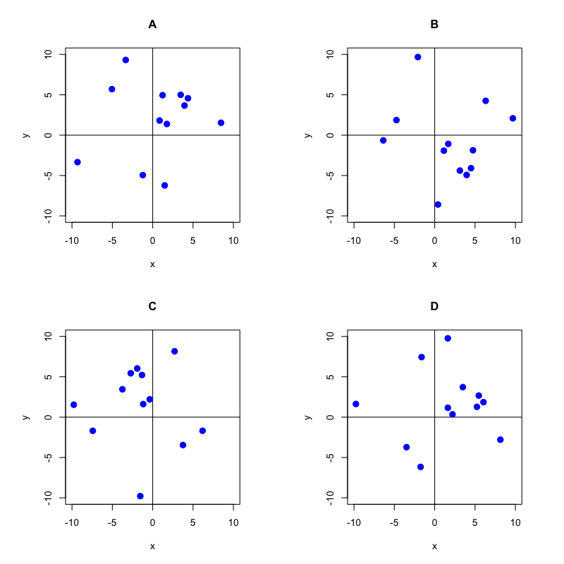

   1. A
   2. B
   3. C
   4. D

#### Question

## Matrix of original points (preimage)

5. A list of 2D-cartesian points is stored as the preimage matrix. Each column represents one point.

   $$P = \begin{bmatrix}
   4 & 7 & 2 & 6 & 2 & -1 & 7 & 5 & 6 & 1 & 7\\
   -1 & -7 & 2 & -4 & 4 & 3 & -1 & -1 & 2 & 3 & -3
   \end{bmatrix}$$

   ```
   P = matrix([[4,7,2,6,2,-1,7,5,6,1,7],[-1,-7,2,-4,4,3,-1,-1,2,3,-3]])
   ```

## Rotation matrix

   We want to rotate the points by $\theta=5.74$ radians counterclockwise. We will do this by [matrix multiplication with the 2D rotation matrix](https://en.wikipedia.org/wiki/Rotation_matrix).

   $$R = \begin{bmatrix}\cos(\theta) & -\sin(\theta) \\ \sin(\theta) & \cos(\theta) \end{bmatrix}$$

## Image

   We can apply the rotation to the points through matrix multiplication. Remember, matrix multiplication is not commutative. Let $T$ represent a matrix holding the final positions of the image (after the transformation).

   $$T = RP$$

   After you calculate $T$, you can plot the points in $T$ with the following code (in SageMath):

   ```
   point(T.transpose(),xmin=-10,xmax=10,ymin=-10,ymax=10,size=50)
   ```

   Which is the graph of the points in $T$? (Please excuse minor stylistic differences due to my graphs being made in R, not SageMath.)

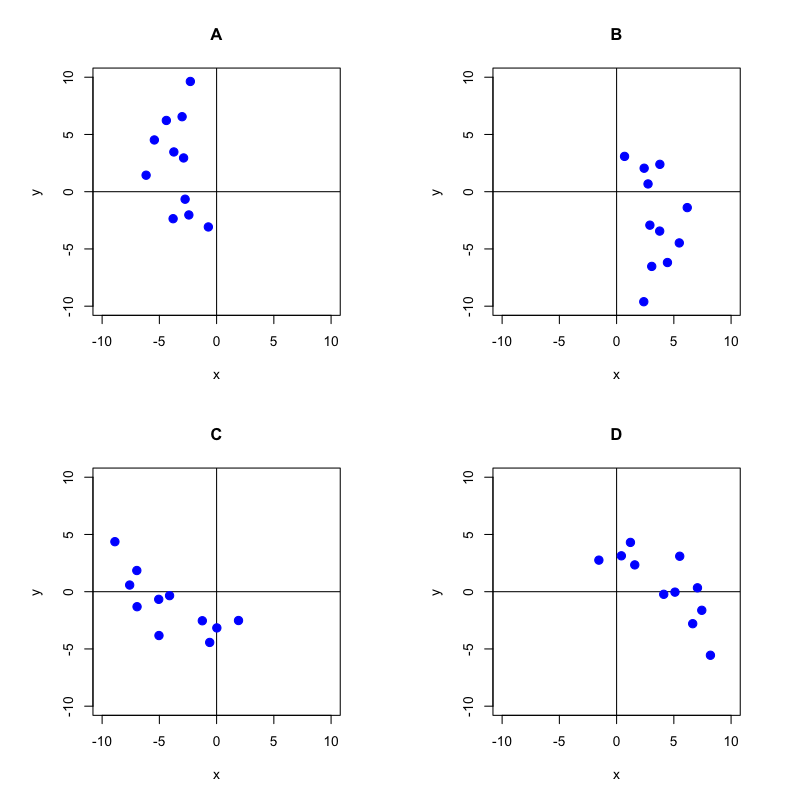

   1. A
   2. B
   3. C
   4. D

#### Question

## Matrix of original points (preimage)

6. A list of 2D-cartesian points is stored as the preimage matrix. Each column represents one point.

   $$P = \begin{bmatrix}
   -4 & 7 & 1 & -1 & -7 & 1 & 7 & -7 & 3 & 7 & -2 & -6\\
   6 & -6 & 7 & 0 & 0 & 3 & 0 & -6 & 0 & -2 & -3 & -5
   \end{bmatrix}$$

   ```
   P = matrix([[-4,7,1,-1,-7,1,7,-7,3,7,-2,-6],[6,-6,7,0,0,3,0,-6,0,-2,-3,-5]])
   ```

## Rotation matrix

   We want to rotate the points by $\theta=4.81$ radians counterclockwise. We will do this by [matrix multiplication with the 2D rotation matrix](https://en.wikipedia.org/wiki/Rotation_matrix).

   $$R = \begin{bmatrix}\cos(\theta) & -\sin(\theta) \\ \sin(\theta) & \cos(\theta) \end{bmatrix}$$

## Image

   We can apply the rotation to the points through matrix multiplication. Remember, matrix multiplication is not commutative. Let $T$ represent a matrix holding the final positions of the image (after the transformation).

   $$T = RP$$

   After you calculate $T$, you can plot the points in $T$ with the following code (in SageMath):

   ```
   point(T.transpose(),xmin=-10,xmax=10,ymin=-10,ymax=10,size=50)
   ```

   Which is the graph of the points in $T$? (Please excuse minor stylistic differences due to my graphs being made in R, not SageMath.)

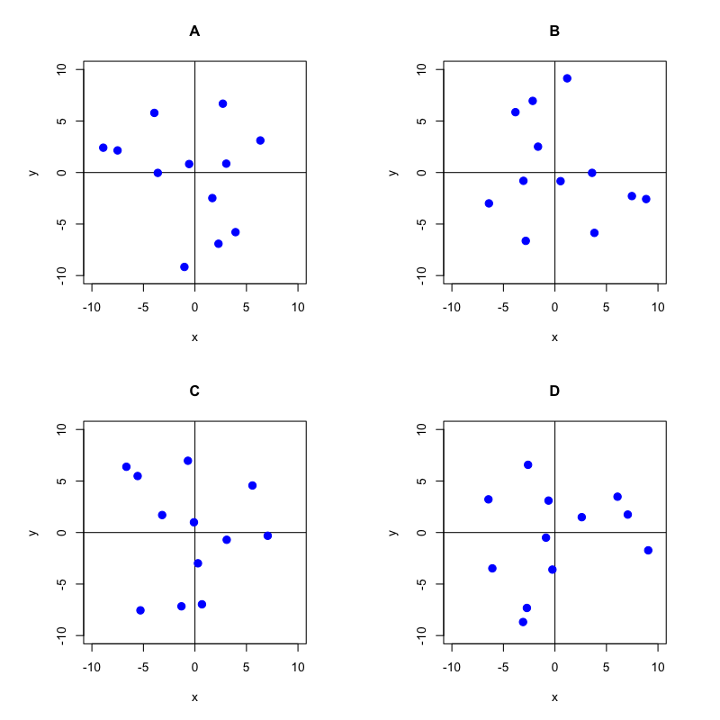

   1. A
   2. B
   3. C
   4. D

#### Question

## Matrix of original points (preimage)

7. A list of 2D-cartesian points is stored as the preimage matrix. Each column represents one point.

   $$P = \begin{bmatrix}
   2 & -2 & 6 & -3 & 2 & 1 & 1 & 7 & -3 & 1\\
   -4 & 5 & -2 & -6 & 3 & -6 & -3 & -6 & -4 & 2
   \end{bmatrix}$$

   ```
   P = matrix([[2,-2,6,-3,2,1,1,7,-3,1],[-4,5,-2,-6,3,-6,-3,-6,-4,2]])
   ```

## Rotation matrix

   We want to rotate the points by $\theta=0.59$ radians counterclockwise. We will do this by [matrix multiplication with the 2D rotation matrix](https://en.wikipedia.org/wiki/Rotation_matrix).

   $$R = \begin{bmatrix}\cos(\theta) & -\sin(\theta) \\ \sin(\theta) & \cos(\theta) \end{bmatrix}$$

## Image

   We can apply the rotation to the points through matrix multiplication. Remember, matrix multiplication is not commutative. Let $T$ represent a matrix holding the final positions of the image (after the transformation).

   $$T = RP$$

   After you calculate $T$, you can plot the points in $T$ with the following code (in SageMath):

   ```
   point(T.transpose(),xmin=-10,xmax=10,ymin=-10,ymax=10,size=50)
   ```

   Which is the graph of the points in $T$? (Please excuse minor stylistic differences due to my graphs being made in R, not SageMath.)

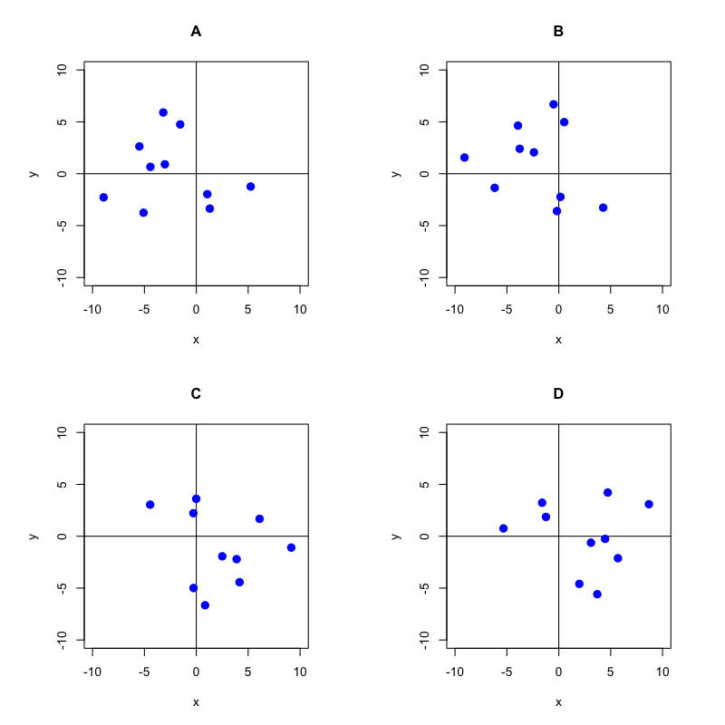

   1. A
   2. B
   3. C
   4. D

#### Question

## Matrix of original points (preimage)

8. A list of 2D-cartesian points is stored as the preimage matrix. Each column represents one point.

   $$P = \begin{bmatrix}
   -3 & -6 & -2 & 1 & 3 & -1 & 3 & 6 & -2 & -6 & 5\\
   7 & -1 & -1 & 1 & 5 & 2 & -2 & 1 & 4 & -1 & -2
   \end{bmatrix}$$

   ```
   P = matrix([[-3,-6,-2,1,3,-1,3,6,-2,-6,5],[7,-1,-1,1,5,2,-2,1,4,-1,-2]])
   ```

## Rotation matrix

   We want to rotate the points by $\theta=5.94$ radians counterclockwise. We will do this by [matrix multiplication with the 2D rotation matrix](https://en.wikipedia.org/wiki/Rotation_matrix).

   $$R = \begin{bmatrix}\cos(\theta) & -\sin(\theta) \\ \sin(\theta) & \cos(\theta) \end{bmatrix}$$

## Image

   We can apply the rotation to the points through matrix multiplication. Remember, matrix multiplication is not commutative. Let $T$ represent a matrix holding the final positions of the image (after the transformation).

   $$T = RP$$

   After you calculate $T$, you can plot the points in $T$ with the following code (in SageMath):

   ```
   point(T.transpose(),xmin=-10,xmax=10,ymin=-10,ymax=10,size=50)
   ```

   Which is the graph of the points in $T$? (Please excuse minor stylistic differences due to my graphs being made in R, not SageMath.)

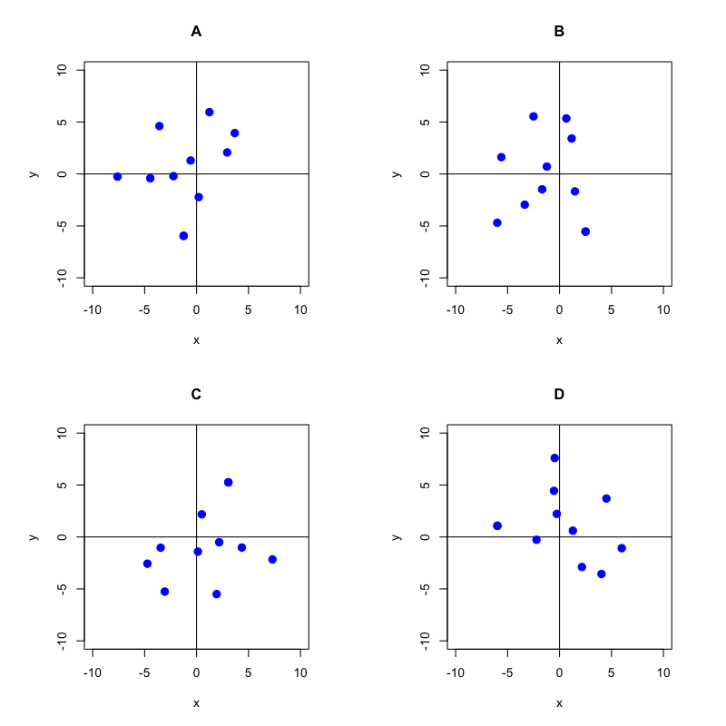

   1. A
   2. B
   3. C
   4. D